# Exercise 2_2: Basic Raster Operations

Introduction to Geospatial Techniques for Social Scientists in R

Author

Stefan Jünger, Anne-Kathrin Stroppe, Dennis Abel

### Exercises

**Note🏋️ Exercise 1**

Create a matrix with 8 rows and 8 columns filled with random numbers between 1 and 1000.

**Caution💡 Tip**

You can create the numbers using the `sample()` function.

**Note🏋 Exercise 2**

Now, use this matrix to create a raster layer and plot it.

**Caution💡 Tip**

The `terra::rast()` function can be fed with matrices to create a raster layer.

The `terra::rast()` function can not only be used to create raster data on the fly, but it is also quite dull. Instead, we can use it to import already prepared data.

**Note🏋 Exercise 3**

Import one of the raster `.tif` files in the `data` folder of the workshop directory. Have a look at it!

**Caution💡 Tip**

Make sure your file paths are set correctly. You can check them with `getwd()`. Setting is done with `setwd()`.

**Note🏋️ Exercise 4**

Import the raster data on inhabitants and citizens in Cologne. Create a new layer showing the proportion of immigrants (!) in each grid cell between 0 and 1.

**Caution💡 Tip**

You can handle raster layers as any simple data table using `+`, `-`, or `/` operators, e.g., to create a new layer that you might need. But make sure to define all missing values first.

### Solutions

**Tip✅ Solution 1**

```r
fancy_matrix <-
  sample(1:1000, 8*8, replace = TRUE) |>
  matrix(nrow = 8, ncol = 8)

fancy_matrix
```

```
     [,1] [,2] [,3] [,4] [,5] [,6] [,7] [,8]
[1,]  466  413  241  535  531  192  643  122
[2,]  714   21  451  144  600   88   37  418
[3,]   73  852  897  482  113  472  238  110
[4,]   53  640  408  408  268  873  282  281
[5,]  704  795  259  732  782  975  753  619
[6,]  311  752  652  332  803  332  991   20
[7,]   23  333  578  370  427  672   12   58
[8,]  859  283  727  829  380  375  341  491
```

**Tip✅ Solution 2**

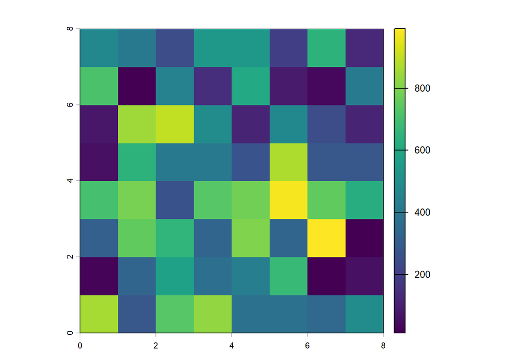

```r
library(terra)
fancy_raster_layer <- terra::rast(fancy_matrix)

terra::plot(fancy_raster_layer)
```

**Tip✅ Solution 3**

```r
# Census 2022 on the number of families
families <- terra::rast("./data/census22_families.tif")

# inspect metadata
families

# plot the data
terra::plot(families)
```

```
class       : SpatRaster
size        : 857, 641, 1  (nrow, ncol, nlyr)
resolution  : 1000, 1000  (x, y)
extent      : 4031000, 4672000, 2691000, 3548000  (xmin, xmax, ymin, ymax)
coord. ref. : ETRS89-extended / LAEA Europe (EPSG:3035)
source      : census22_families.tif
name        : cat_0
min value   :     3
max value   :  4307
```

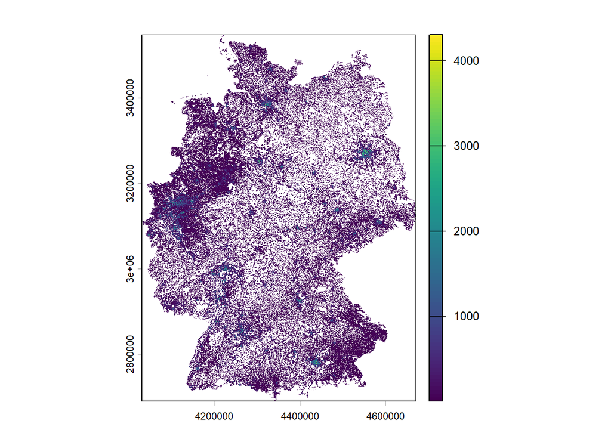

**Tip✅ Solution 4**

```r
# load all layers
citizens_cologne <- terra::rast("./data/citizens_cologne.tif")
inhabitants_cologne <- terra::rast("./data/inhabitants_cologne.tif")

# define missing values
citizens_cologne[citizens_cologne == -9] <- NA
inhabitants_cologne[inhabitants_cologne == -9] <- NA

# create immigrants layer
immigrants_cologne <- inhabitants_cologne - citizens_cologne

# inspect data
immigrants_cologne

# something's off - let's get rid of the wierd negative numbers
immigrants_cologne[immigrants_cologne < 0] <- NA

# create proportation layer
immigrants_proportion <- immigrants_cologne / inhabitants_cologne

# set a proper name for our created layer
names(immigrants_proportion) <- "immigrants_proportion"

# plot it
terra::plot(immigrants_proportion)
```

```
class       : SpatRaster
size        : 290, 266, 1  (nrow, ncol, nlyr)
resolution  : 100, 100  (x, y)
extent      : 4094800, 4121400, 3083900, 3112900  (xmin, xmax, ymin, ymax)
coord. ref. : ETRS89-extended / LAEA Europe (EPSG:3035)
source(s)   : memory
varname     : inhabitants_cologne
name        : cat_0
min value   :    -5
max value   :   516
```

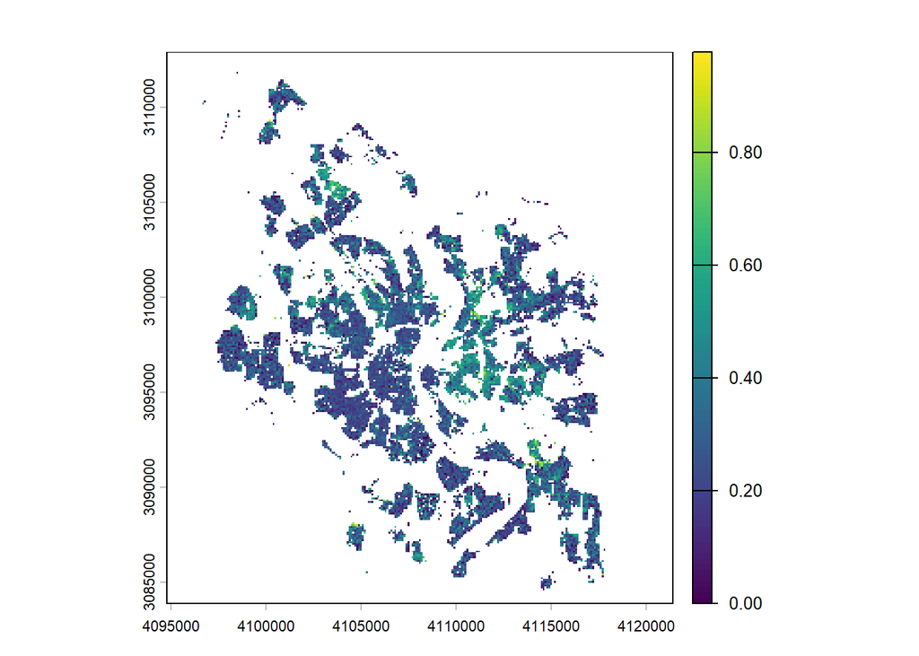